# Introduction

Universities are typically opaque, bureaucratic institutions. To be transparent to tax payers, many public schools, such as the University of North Carolina, openly report **[salary information](http://www.newsobserver.com/news/databases/public-salaries/)**. WE will use recent salary data for UNC-Chapel Hill faculty and staff to perform a rudimentry analysis of trends.

# Data Information

```r
salary=read_csv("UNC_System_Salaries Search and Report.csv")
```

Now, we will explore the information that is contained in this dataset. The code below provides the names of the variables contained in the dataset.

```r
names(salary)
```

```
##  [1] "Name"                  "campus2"               "dept"
##  [4] "position"              "PRIMARY_WORKING_TITLE" "hiredate"
##  [7] "exempt"                "fte"                   "employed"
## [10] "statesal"              "nonstsal"              "totalsal"
## [13] "stservyr"
```

Next, we will examine the type of data contains in these different variables.

```r
str(salary,give.attr=F)
```

```
## spec_tbl_df [12,646 x 13] (S3: spec_tbl_df/tbl_df/tbl/data.frame)
##  $ Name                 : chr [1:12646] "AACHOUI, YOUSSEF" "AARNIO, REA T" "ABAJAS, YASMINA L" "ABARBANELL, JEFFERY S" ...
##  $ campus2              : chr [1:12646] "UNC-CHAPEL HILL" "UNC-CHAPEL HILL" "UNC-CHAPEL HILL" "UNC-CHAPEL HILL" ...
##  $ dept                 : chr [1:12646] "Microbiology and Immunology" "SW-Research Projects" "Peds-Hematology/Oncology" "Kenan-Flagler Bus Sch" ...
##  $ position             : chr [1:12646] "Research Professional, Medical" "Functional Paraprofessional" "Assistant Professor" "Associate Professor" ...
##  $ PRIMARY_WORKING_TITLE: chr [1:12646] "Research Associate" "Graphic Designer" "NODESCR" "Associate Professor" ...
##  $ hiredate             : chr [1:12646] "10/10/2011" "1/14/2013" "7/1/2015" "1/1/1999" ...
##  $ exempt               : chr [1:12646] "Exempt from Personnel Act" "Subject to State Personnel Act" "Exempt from Personnel Act" "Exempt from Personnel Act" ...
##  $ fte                  : num [1:12646] 1 0.8 1 1 1 1 1 1 1 1 ...
##  $ employed             : num [1:12646] 12 12 12 9 12 12 12 9 12 9 ...
##  $ statesal             : logi [1:12646] NA NA NA NA NA NA ...
##  $ nonstsal             : logi [1:12646] NA NA NA NA NA NA ...
##  $ totalsal             : num [1:12646] 49128 33257 139405 181000 41098 ...
##  $ stservyr             : num [1:12646] 1 5 2 20 6 8 6 1 19 1 ...
```

The variable “hiredate” is recorded as a character. The following code will first modify the original dataset to change this to a date variable with the format *yyyymmdd*.

```r
salary$hiredate=as.Date(salary$hiredate, format="%m/%d/%Y")
salary$hiredate=as.numeric(gsub("-","",salary$hiredate))
salary=as.tibble(salary)
head(salary,5)
```

```
## # A tibble: 5 x 13
##   Name   campus2  dept  position PRIMARY_WORKING~ hiredate exempt   fte employed
##   <chr>  <chr>    <chr> <chr>    <chr>               <dbl> <chr>  <dbl>    <dbl>
## 1 AACHO~ UNC-CHA~ Micr~ Researc~ Research Associ~ 20111010 Exemp~   1         12
## 2 AARNI~ UNC-CHA~ SW-R~ Functio~ Graphic Designer 20130114 Subje~   0.8       12
## 3 ABAJA~ UNC-CHA~ Peds~ Assista~ NODESCR          20150701 Exemp~   1         12
## 4 ABARB~ UNC-CHA~ Kena~ Associa~ Associate Profe~ 19990101 Exemp~   1          9
## 5 ABARE~ UNC-CHA~ Inst~ Researc~ Research Techni~ 20110912 Subje~   1         12
## # ... with 4 more variables: statesal <lgl>, nonstsal <lgl>, totalsal <dbl>,
## #   stservyr <dbl>
```

## Part 1: Reducing the Data to a Smaller Set of Interest

```r
salary2 = select(salary,Name,dept,position,hiredate,exempt,totalsal)

names(salary2)
```

```
## [1] "Name"     "dept"     "position" "hiredate" "exempt"   "totalsal"
```

We will modify `salary2` to better label the variables and create new variables that will be useful for analysis.

```r
salary2 = rename(salary2 ,Department=dept,Job=position,Exempt=exempt,Salary=totalsal)
```

```r
salary.final = salary2%>%
  mutate(HireYear = hiredate%/%10000)%>%
  mutate( YrsEmployed = 2017 - HireYear)%>%
  select(-hiredate,-HireYear)%>%
  arrange(Department,YrsEmployed)%>%
  select(YrsEmployed,Salary,everything())
```

## Part 2: Answering Questions Based on All Data

How does expemtion from the State Personnel Act impact salary?

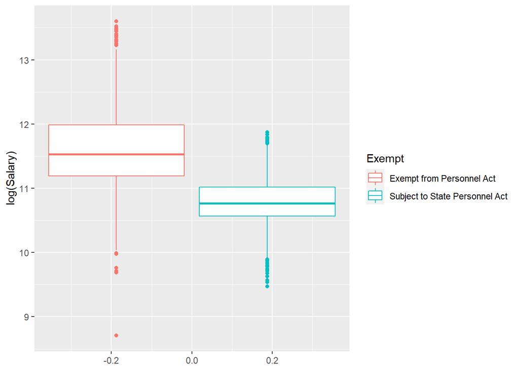

```r
salary.final%>%
  group_by(Exempt)%>%
  ggplot(mapping = aes(y=log(Salary), color=Exempt))+
  geom_boxplot()
```

On average, it appears that those that are exempt from the personnel act have a higher salary. However, there is also a greater spread of data points for those who are exempt from the personnel act. The difference in salary could be due to the type of jobs that are exempt from the personnel act (i.e. doctors, lawyers).

What is the average salary of employees in the Law Department?

```r
salary.final%>%
  filter(Department=="Law")%>%
  summarise(mean = mean(Salary))
```

```
## # A tibble: 1 x 1
##      mean
##     <dbl>
## 1 112567.
```

The mean salary in the Law Department is $112,567.10.

How many employees have worked in Family Medicine between 5 and 8 years (inclusive) and are exempt from personnel act?

```r
salary.final%>%
  filter(Department=="Family Medicine" &
         YrsEmployed >=5 & YrsEmployed <=8 &
         Exempt=="Exempt from Personnel Act")%>%
  summarise(n=n())
```

```
## # A tibble: 1 x 1
##       n
##   <int>
## 1    10
```

10 employees have worked in Family Medicine between 5 and 8 years (inclusive) and are exempt from personnel act.

What is the mean salary of employees from the Linguistics department who are professors, associate professors, or assistant professors?

```r
salary.final%>%
  filter((Department=="Linguistics"))%>%
  filter(Job=="Professor"|Job=="Associate Professor"|Job=="Assistant Professor")%>%
   summarise(mean = mean(Salary))
```

```
## # A tibble: 1 x 1
##     mean
##    <dbl>
## 1 79935.
```

The mean salary of employees from the Linguistics department who are professors, associate professors, or assistant professors is $79,935.17.

Based off the data in `salary.final`, let’s create a grouped summary based off combinations of “Department” and “YrsEmployed” that reports the following statistics:

- “n” = number of employees for each combination
- “mean” = average salary for each combination
- “sd” = standard deviation of salary for each combination.
- “min” = minimum salary for each combination.
- “max” = maximum salary for each combination

```r
deptyear_summary = as.tibble(salary.final)%>%
  group_by(Department,YrsEmployed)%>%
  summarise(n=n(),
            mean=mean(Salary),
            sd = sd(Salary),
            min=min(Salary),
            max=max(Salary))%>%
  ungroup()
head(deptyear_summary,10)
```

```
## # A tibble: 10 x 7
##    Department                YrsEmployed     n   mean     sd   min   max
##    <chr>                           <dbl> <int>  <dbl>  <dbl> <dbl> <dbl>
##  1 A and S - Business Center           0     4 46522   4584  39646 48814
##  2 A and S - Business Center           1     4 43610.  4589. 39646 47983
##  3 A and S - Business Center           2     2 48398.   588. 47983 48814
##  4 A and S - Business Center           3     2 52190.  2703. 50278 54101
##  5 A and S - Business Center           4     2 54488   9199. 47983 60993
##  6 Acad Initiatives-UBC                1     1 23250     NA  23250 23250
##  7 Acad Initiatives-UBC                3     1 48782     NA  48782 48782
##  8 Acad Initiatives-UBC                6     1 60341     NA  60341 60341
##  9 Acad Initiatives-UBC                7     1 54851     NA  54851 54851
## 10 Acad Initiatives-UBC               14     2 64916  12875. 55812 74020
```

Using the summarized data in `deptyear_summary`, let’s see which 3 departments award the lowest average salary for employees who have been employed for 3 years.

```r
q10 = deptyear_summary%>%
  filter(YrsEmployed == 3)%>%
  filter(dense_rank(mean)%in% 1:3)
q10
```

```
## # A tibble: 5 x 7
##   Department                    YrsEmployed     n   mean    sd    min    max
##   <chr>                               <dbl> <int>  <dbl> <dbl>  <dbl>  <dbl>
## 1 DPS Security                            3     3 26569. 6896. 18627. 31047.
## 2 FS-Housekeeping Svcs-Zone 13            3     1 26680.   NA  26680. 26680.
## 3 FS-Housekeeping Svcs-Zone 16            3     1 26680.   NA  26680. 26680.
## 4 FS-Housekeeping Svcs-Zone 18            3     2 26680.    0  26680. 26680.
## 5 TEACCH - Supported Employment           3     2 26041. 5261. 22321  29761.
```

The three lowest departments based on mean salary are DPS Security, FS-Housekeeping Svcs-Zone 13,FS-Housekeeping Svcs-Zone 13,FS-Housekeeping Svcs-Zone 13, TEACHH-Supported Employment. Notice that the std deviation is NA because there is only one entry that matches the salary value for a faculty working inFS-Housekeeping Svcs-Zone 13 for 3 years. Without multiple matching entries for the criteria, std deviation cannot be calculated.

Let’s create a scatter plot to visualize the relationship between average salary and the years employed.

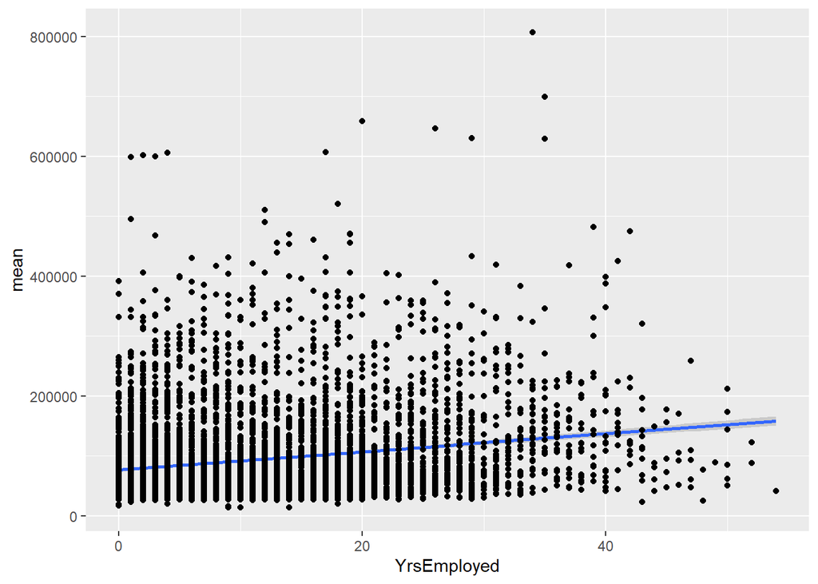

```r
ggplot(data = deptyear_summary, mapping = aes(x=YrsEmployed, y=mean)) +
  geom_smooth(method="lm")+
  geom_point()
```

There appears to be a weak positive correlation between years employed and mean salary for UNC employees. Let’s see if this relationship is stronger for employees with the word Professor in their job title.

```r
dict <- c("Professor")

salaryprof <- salary.final %>% mutate(row=row_number()) %>% select(row, everything())

counts <- salaryprof %>% tidyr::separate_rows(Job) %>% filter(Job %in% dict) %>% group_by(row) %>% count(name = "counts")

proffinal <- left_join(salaryprof, counts, by="row") %>% tidyr::replace_na(list(counts=0L))
proffinal <- proffinal%>% filter(counts>0)
```

```r
deptyear_summary1 = as.tibble(proffinal)%>%
  group_by(Department,YrsEmployed)%>%
  summarise(n=n(),
            mean=mean(Salary),
            sd = sd(Salary),
            min=min(Salary),
            max=max(Salary))%>%
  ungroup()
```

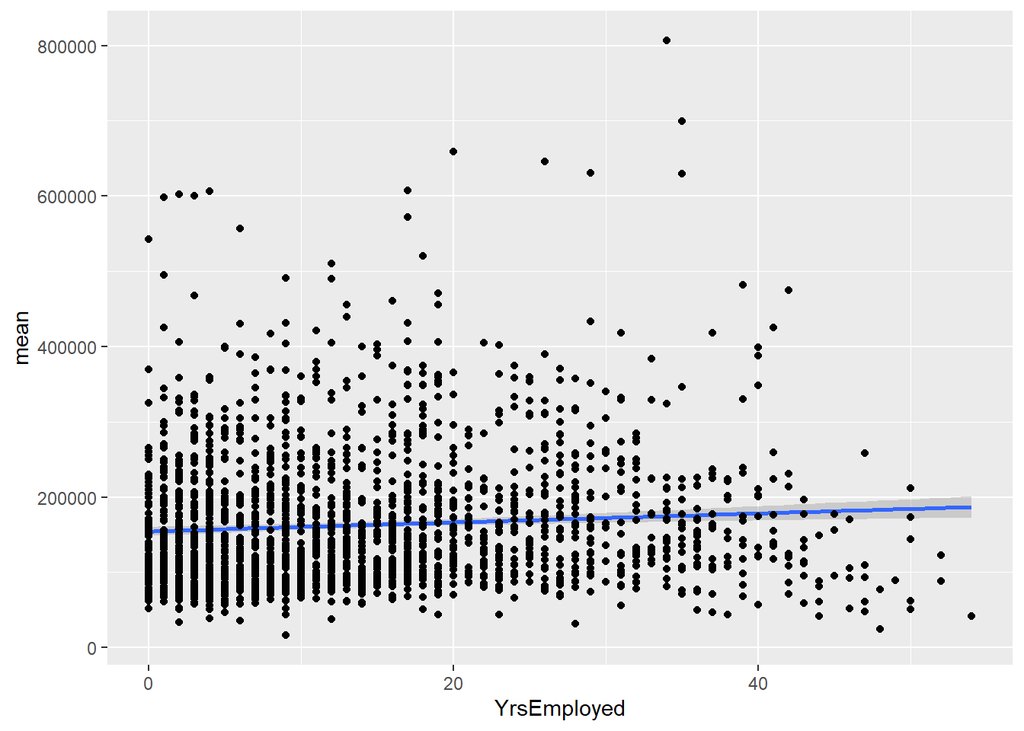

```r
ggplot(data = deptyear_summary1, mapping = aes(x=YrsEmployed, y=mean)) +
  geom_smooth(method="lm")+
  geom_point()
```

Surprisingly, it appears that the relationship between years employed and mean salary is even weaker for those whose job titles contain “Professor”. This could be explained by the fact that these employees start off with a higher salary, on average, so there is possibly less room to grow.

Let’s dive deeper into the linear relationship depicted above using 5 specific departments: SW-Research Projects’,‘Kenan-Flagler Bus Sch’, ‘Med Ad-Human Resources’,‘Dramatic Art’and ’School of Education Deans Ofc’.

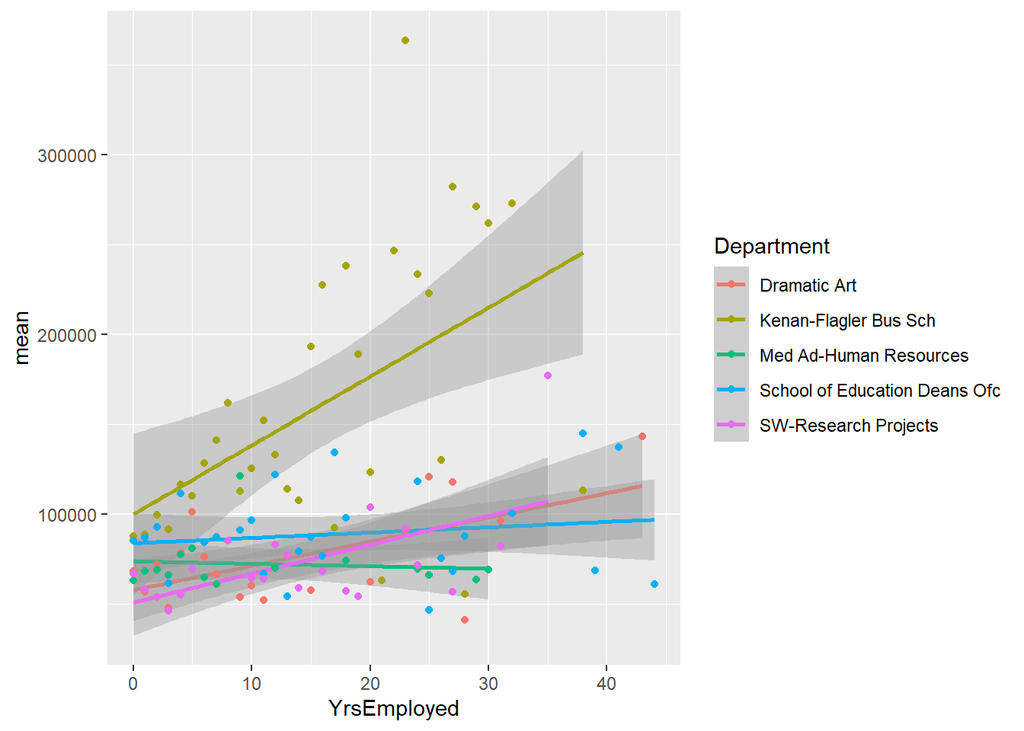

```r
depts = c('SW-Research Projects','Kenan-Flagler Bus Sch', 'Med Ad-Human Resources','Dramatic Art','School of Education Deans Ofc')
q12 = deptyear_summary%>%
  filter(Department%in%c(depts))

ggplot(data = q12, mapping = aes(x=YrsEmployed, y=mean,color=Department))+
  geom_smooth(method="lm")+
  geom_point()
```

As shown through the graph, the average starting salary varies for all the departments. SW-Research Projects and Dramatic Art have similar starting salaries as do School of Education Deans Ofc and Med Ad-Human Resources. The highest average starting salary is in Kenan-Flager Bus Sch. In terms of correlation between years employed and average starting salary, all but the Med-Ad Human Resources have a positive relationship. The strongest positive correlation is in the Kenan-Flager Bus School while the weakest positive relationship is in the School of Education Deans Ofc,